# Recitation 11

Anique Tahir

## Outline

- Hindley Milner Type Inference
- Exam Review

## Notation for operations

We will be using OCaml notation for Hilney Milner Type Inference

- Arrays are represented as a.(i)
- + operator only works on `int`'s
- +. represents float addition
- < and > take operands of type int, real, string, and functions

## OCaml Type Inference Examples

```
let f x y = x (y+1);;
```

```
let max x y = if x>y then x else y;;
```

```python
%load_ext hierarchymagic
```

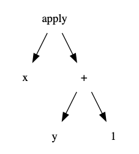

```python
%%dot
digraph D {
    apply[shape=none]
    x[shape=none]
    plus[shape=none, label="+"]
    y[shape=none]
    one[shape=none, label="1"]

    apply->x;
    apply->plus;
    plus->y;
    plus->one;
}
```

## Hilney Milner Algorithm

- Create an Abstract Syntax Tree
- Associate with each named variable a type
- Associate with each node of the AST a type
- Resolve the types of each node using constraints

## Example

```
let f x y g = if g x y then x else y;;
```

## Exercise

**Problem 1**

Given

```
let f x y = if  x ( x y ) then 1 else 2
```

**Problem 2**

Given

```
let f x y = x (x y)
```

Use Hilney Milner Type inference to resolve the Types

## Exam Questions Review

```
The term fls FIRST FOLLOW where FIRST and FOLLOW are two terms evaluates to

a. FIRST
b. FOLLOW
c. EOF
d. Ɛ
e. none of the above
```

```
The term 3(times 2)(fst(pair 2 3)) evaluates to

a. 2
b. 4
c. 6
d. 16
e. 18
```

# Questions(Contd)

Given

$\lambda$x. ($\lambda$y. ($\lambda$z. z) y) x ( x ($\lambda$w. w ) x )

In normal order evaluation, the term above reduces in one step to

a.($\lambda$y. ($\lambda$z. z) x) (x ($\lambda$w. w ) x )

b. $\lambda$x. ($\lambda$y. ($\lambda$z. z) y) x (x x )

c. $\lambda$x.(($\lambda$x. x) x) (x ($\lambda$w. w ) x )

d. $\lambda$x.(($\lambda$z. z) x) (x ($\lambda$w. w ) x )

e. cannot be reduced

Given

$\lambda$x. ($\lambda$y. ($\lambda$z. z) y) x ( x ($\lambda$w. w ) x )

In call by value, the term above reduces in one step to

a.($\lambda$y. ($\lambda$z. z) x) (x ($\lambda$w. w ) x )

b. $\lambda$x. ($\lambda$y. ($\lambda$z. z) y) x (x x )

c. $\lambda$x.(($\lambda$x. x) x) (x ($\lambda$w. w ) x )

d. $\lambda$x.(($\lambda$z. z) x) (x ($\lambda$w. w ) x )

e. cannot be reduced

```
The expression 3(plus 2) 3
evaluates to

a. 8
b. 9
c. 3 5
d. 5 3
e. none of the above
```

```
The expression scc2 (times 3) 2
evaluates to

a. 18
b. 27
c. 54
d. 19
e. none of the above
```

init= pair 0 0

next1 = $\lambda$p. times (scc(sndp)) (scc(sndp))

next2 = $\lambda$p. pair (next1 p) (scc(sndp))

mystery = $\lambda$n. n next2 init

What does the mystery function calculate when applied to a Church numeral?